# Comparing networks

Nikolas Gestrich, Juan-Marco Puerta-Schardt

6/8/2021

This document will show some basic ways in which networks can be compared. For archaeologists, this might be used to compare networks made on the same set of sites but whose edges are made on different materials, or for comparing different regions, or to assess the change of a network through time. The latter is what we will demonstrate here, using the Michelsberg data from the preceding instructions.

# Making the networks

The Michelsberg dataset contains a number of different periods.

```r
#get data
library(archdata)
data(Michelsberg)
#this command will give us a list of periods and how many entries there are of each
Michelsberg %>% count(mbk_phase)
```

```
##    mbk_phase  n
## 1          I  4
## 2       I/II  5
## 3         II 14
## 4     II/III  9
## 5        III 24
## 6      III-V  1
## 7     III/IV  6
## 8         IV  9
## 9       IV/V  7
## 10      Munz 14
## 11         V 16
```

We can see that there are a lot of in between phases or uncertain attributions, and that there is quite a difference in the number of entries. In this case, we will artificially collapse these groups to make the numbers even, though we would need to justify this based on external arguments if this was real research work. As it is, we will place I together, with I/II, remove II/III, group III/IV with IV, and remove IV/V.

```r
mbkphases <- Michelsberg %>%        #make a new dataset with modifications
                                    #adding the old phases to a new, simplified, phase column
  mutate(phase = case_when(mbk_phase == "I/II"| mbk_phase == "I" ~ 1,
                           mbk_phase == "II" ~ 2,
                           mbk_phase == "III" ~ 3,
                           mbk_phase == "III/IV"| mbk_phase == "IV" ~ 4,
                           TRUE ~ NA_real_))

# Look at the new phases
mbkphases %>% count(phase)
```

```
##   phase  n
## 1     1  9
## 2     2 14
## 3     3 24
## 4     4 15
## 5    NA 47
```

We now have four phases which have a tolerable number of observations in each. We will now make a network for each of them using the commands we learnt in the “Preparing data” file.

```r
# to save us from typing too much, we will make a little function
select.phase <- function(p){
  mbkphases %>%
    filter(phase == p) %>% # select only relevant phase
    distinct(site_name, .keep_all=TRUE) %>% # our phase groupings have led to duplicate sites, which we remove here. Note that this just a shortcut to clean data and has no scientific reason. You would want to do this differently in real life.
    select(5:39)  # select all columns that contain information on the amount of the different pottery types
}

mbk2 <- mbkphases %>% filter(phase == 2) %>% distinct(site_name, .keep_all=TRUE)


# now apply this to the phases
mbk1 <- select.phase(1)
mbk2 <- select.phase(2)
mbk3 <- select.phase(3)
mbk4 <- select.phase(4)

#From these four datasets, we will now make edgelists
mbk1edges <- make.edgelist(mbk1)
mbk2edges <- make.edgelist(mbk2)
mbk3edges <- make.edgelist(mbk3)
mbk4edges <- make.edgelist(mbk4)
```

```r
#The nodelist can be the same for all phases, we will trim the extraneous nodes later
mbknodes <- Michelsberg %>%
  rownames_to_column(var = "site_feature") %>%  # make the rownames into a separate column
  select(site_feature, site_name, feature_nr, x_utm32n, y_utm32n) %>%   # select the columns we want
  rename(lon = x_utm32n, lat = y_utm32n, id = site_feature) #change some of the more unwieldy names

#Now, we will create four graphs
mbk1net <- tbl_graph(nodes = mbknodes, edges = mbk1edges, directed = FALSE)
mbk2net <- tbl_graph(nodes = mbknodes, edges = mbk2edges, directed = FALSE)
mbk3net <- tbl_graph(nodes = mbknodes, edges = mbk3edges, directed = FALSE)
mbk4net <- tbl_graph(nodes = mbknodes, edges = mbk4edges, directed = FALSE)

#At the end of this section, let's do a little housekeeping and get rid of the datasets we won't be needing anymore:
rm(mbk1, mbk2, mbk3, mbk4, mbkphases)
```

We have now created four networks which represent four different stages of the Michelsberg culture. We want to know what changes in these networks and what this might mean for the social networks that exchanged pottery types. Did they change? In what way?

# Visual comparison

It is often a good idea to have a visual exploration of the data in the first place. So just for this, we will make some quick representations of the four graphs.

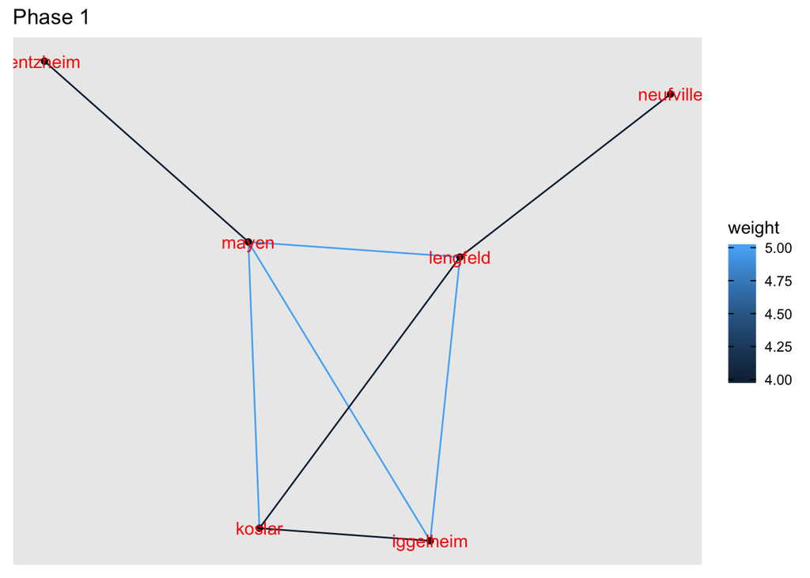

```r
#Because we have to run the same steps on four graphs, we will write some helper functions. This is where R comes into its own. Imagine the number of clicks you would have to do on UCInet or similar to get this!

#first we make a function for thresholding:
thresh.graph <- function(data,x){
  data %>%
    activate(edges) %>%  # select the edges for transformation
    filter(weight >= x) %>%  # remove all connections below a specified number of shared types
    activate(nodes) %>%  # select nodes for transformation
    filter(!node_is_isolated())  # remove all nodes that do not have a connection
}

#Then we set out our graphics options to shorten the commands
red.weight <- list(
                geom_edge_link(aes(color = weight)),  # color edges according to weight
                geom_node_point(), # add a point for each node
                geom_node_text(aes(label = site_name), color = "red") # add labels to the nodes
                )

#Now we can quickly return the four graphs

mbk1net %>% thresh.graph(4) %>% ggraph(layout = "stress")+ red.weight + labs(title = "Phase 1")
```

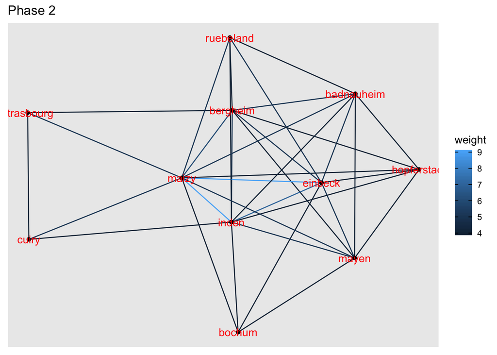

```r
mbk2net %>% thresh.graph(4) %>% ggraph(layout = "stress")+ red.weight + labs(title = "Phase 2")
```

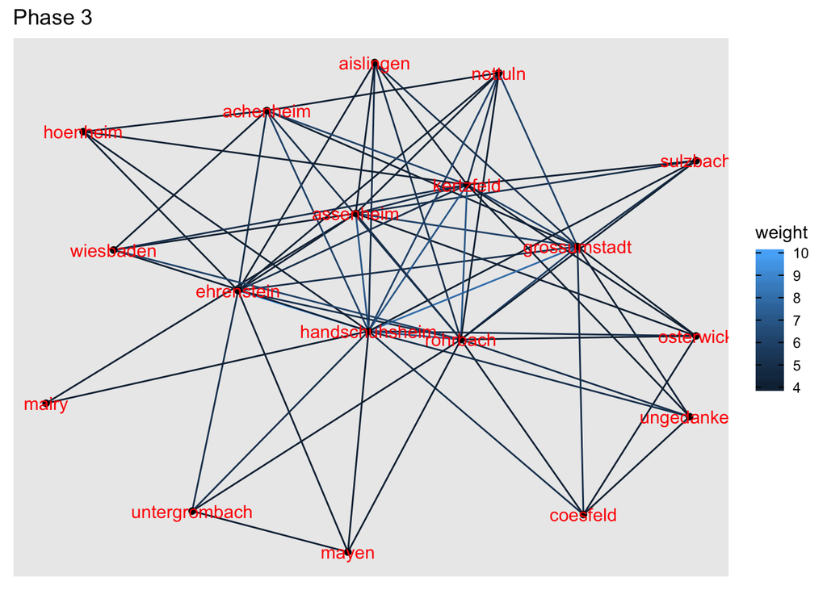

```r
mbk3net %>% thresh.graph(4) %>% ggraph(layout = "stress")+ red.weight + labs(title = "Phase 3")
```

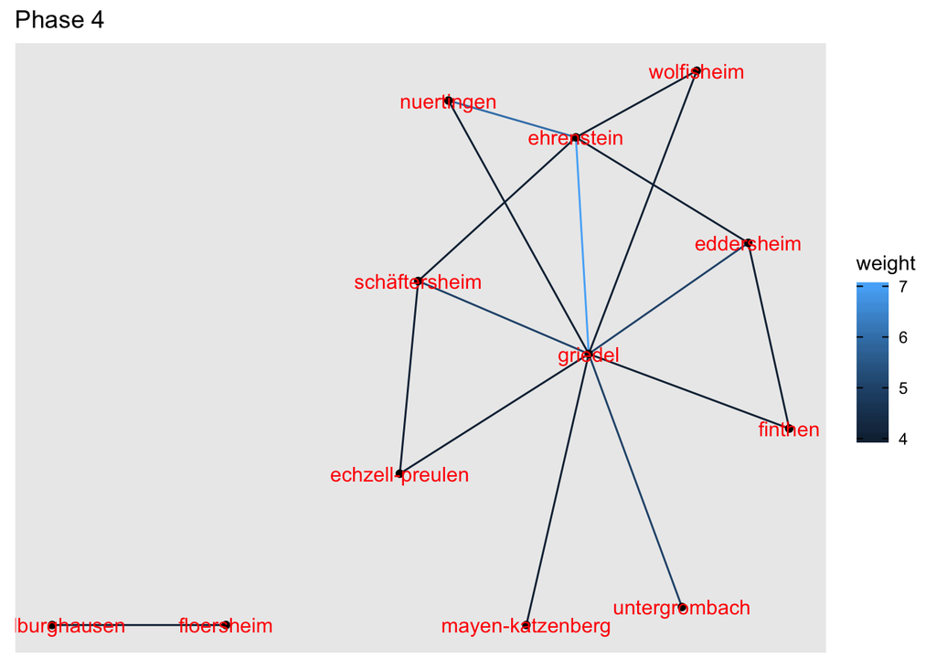

```r
mbk4net %>% thresh.graph(4) %>% ggraph(layout = "stress")+ red.weight + labs(title = "Phase 4")
```

Having had a look at the graph, and played around with the thresholds, we think we can see that the two middle Phases are much more connected than phases 1 and 4. But to really find out what changes, we will have to rely on network measures. We will first begin with measures on the whole network, then move on to measures on the nodes and edges.

# Network comparison

There are a great number of measures that might characterise a graph. Here, we will use the following as an example:

- size: how many edges does the graph have?
- order: how many nodes does the graph have?
- mean distance: What is the mean distance between any two nodes?
- edge connectivity : How many edges would have to be removed to make the graph become disconnected?
- clustering coefficient : How closed or clustered is the network (what is its tendency to form closed triangles)?
- density: how densely is the graph connected?

```r
# Make a function to get together the measures we want in a table
netmeasures <- function(graph, thresh, phase){

  trans <- graph %>%
  thresh.graph(thresh) %>%
  igraph::transitivity()  # calculate transitivity

  dens <- graph %>%
  thresh.graph(thresh) %>%
  igraph::graph.density()  # calculate density

  graph %>%
    thresh.graph(thresh) %>%
    mutate(meandist = graph_mean_dist(),  # calculate mean distance
         size = graph_size(),  # number of edges
         order = graph_order(),  # number of nodes
         connectivity = graph_adhesion()) %>%  # connectivity
    select(meandist, size, order, connectivity) %>%  # select measures
    as_tibble() %>%  # turn into dataframe
    head(1) %>%   # select only first row (as data is repetitive)
    mutate(phase = phase,
           transitivity = trans,
           density = dens) %>%   # add all measures together
    select(phase, everything())  # order phase to the front
}

# Now apply the function
a <- netmeasures(mbk1net, 3, 1)
b <- netmeasures(mbk2net, 3, 2)
c <- netmeasures(mbk3net, 3, 3)
d <- netmeasures(mbk4net, 3, 4)

#make a table of all phases
phase.measures <- bind_rows(a,b,c,d)

#housekeeping
rm(a,b,c,d)

#let's have a look at the table
phase.measures
```

```
## # A tibble: 4 x 7
##   phase meandist  size order connectivity transitivity density
##   <dbl>    <dbl> <dbl> <int>        <dbl>        <dbl>   <dbl>
## 1     1     1.31    25     9            2        0.767   0.694
## 2     2     1.15    47    11            6        0.871   0.855
## 3     3     1.48   118    21            1        0.745   0.562
## 4     4     1.54    46    14            1        0.688   0.505
```

We see that there is quite a distance in size and order between the phases, but that it is never far from one node to another. This is due to the nature of the network: when it is about co-occurrences like this one is, we would not expect too much distance.

More interesting are the remaining measures, which all correlate to show that Phase 2 is the most closely connected. The high connectivity means that the assemblages were most homogeneous in this phase, and that therefore the social contacts between the sites shared a similar range of objects. While the number of connections increases in Phase 3, so too does the fragility of the network, which might indicate that groups formed. On this basis we could say that the Michelsberg culture found its strongest cohesion and most resembled a unified social group during Lüning’s phase II. In his Phase III, a fragmentation sets in which continues through Phase IV.

This goes some way to show how different these results are from what we might find out by distribution maps, and also from the seriation that was done with this data previously. SNA allows us to assess the social processes behind artefact distribution patterns, provided we have a strong hypothesis to link the two.

# Centralities

Within this dynamic, what were the key sites? This is a question we will ask of measures on the nodes within our networks. We have explained these previously and here we will be using:

- degree centrality
- betweenness centrality
- eigenvector centrality

```r
#Once again, we wil make a function
centralities <- function(graph, thresh, phase){

  graph %>%
  thresh.graph(thresh) %>%
  activate(nodes) %>%  # select nodes for transformation
  mutate(degree = centrality_degree(weights = weight),
         betweenness = centrality_betweenness(weights = weight),
         eigen = centrality_eigen(weights = weight),
         phase = phase) %>%
  as_tibble() %>%
  select(phase, id, site_name, degree, betweenness, eigen)
}

# Apply the function to each network
p1 <- centralities(mbk1net, 3, 1)
p2 <- centralities(mbk2net, 3, 2)
p3 <- centralities(mbk3net, 3, 3)
p4 <- centralities(mbk4net, 3, 4)

#make a dataset containing all phases
centrality <- bind_rows(p1,p2,p3,p4)

#housekeeping
rm(p1,p2,p3,p4)
```

These datasets are now the basis for us to have a look at centrality in a couple of ways: by measure, and by site. If we look at them by measure, we can find out what the highest-scoring nodes in each network are.

```r
#we will look at the development of degree centrality
degree <- centrality %>%
  select(phase, site_name, degree) %>%  #take only relevant columns
  pivot_wider(names_from = phase, values_from = degree) %>%  # make the long data wide
  tibble()
```

```r
#we will look at this as a table
library(knitr)
options(knitr.kable.NA = "")
kable(degree)
```

| site_name | 1 | 2 | 3 | 4 |
| --- | --- | --- | --- | --- |
| achenheim | 6 |  | 53 |  |
| entzheim | 16 |  |  |  |
| iggelheim | 23 |  |  |  |
| lengfeld | 30 |  |  |  |
| aldenhoven | 12 |  |  |  |
| koslar | 25 |  |  |  |
| miel | 15 |  |  |  |
| mayen | 31 | 37 | 34 |  |
| neufville | 16 |  |  |  |
| strasbourg |  | 25 |  |  |
| hopferstadt |  | 30 |  |  |
| badnauheim |  | 37 |  |  |
| bergheim |  | 43 |  |  |
| einbeck |  | 50 |  |  |
| ruebeland |  | 31 |  |  |
| bochum |  | 25 |  |  |
| inden |  | 49 |  |  |
| cuiry |  | 22 |  |  |
| maizy |  | 57 |  |  |
| hoenheim |  |  | 34 |  |
| kertzfeld |  |  | 78 |  |
| handschuhsheim |  |  | 99 |  |
| rohrbach |  |  | 81 |  |
| untergrombach |  |  | 42 | 29 |
| aislingen |  |  | 42 |  |
| ehrenstein |  |  | 67 | 43 |
| grossumstadt |  |  | 79 |  |
| rauenthal |  |  | 6 |  |
| sulzbach |  |  | 40 |  |
| wackernheim |  |  | 12 |  |
| wiesbaden |  |  | 35 |  |
| assenheim |  |  | 67 |  |
| ungedanken |  |  | 46 |  |
| coesfeld |  |  | 37 |  |
| osterwick |  |  | 34 |  |
| nottuln |  |  | 51 |  |
| urmitz |  |  | 3 |  |
| mairy |  |  | 26 |  |
| wolfisheim |  |  |  | 23 |
| bolanden |  |  |  | 3 |
| goldburghausen |  |  |  | 16 |
| nuertingen |  |  |  | 19 |
| schäftersheim |  |  |  | 28 |
| eddersheim |  |  |  | 28 |
| floersheim |  |  |  | 31 |
| finthen |  |  |  | 23 |
| frankfurt-praunheim |  |  |  | 9 |
| echzell-preulen |  |  |  | 14 |
| griedel |  |  |  | 45 |
| mayen-katzenberg |  |  |  | 13 |

One of the things we see when we look at this data is that there is not much point in comparing in a systematic manner, since the sites are different for each phase. Only some sites occur in more than one phase, and only Mayen occurs in more than two. If you had the same sites in a network developing through time, this would be a worthwhile step.

Another way we can look at a measure is by checking its distribution by phase. Of course you can do this in a table, but we will visualise it here using a ridge plot form the `ggridges` package.

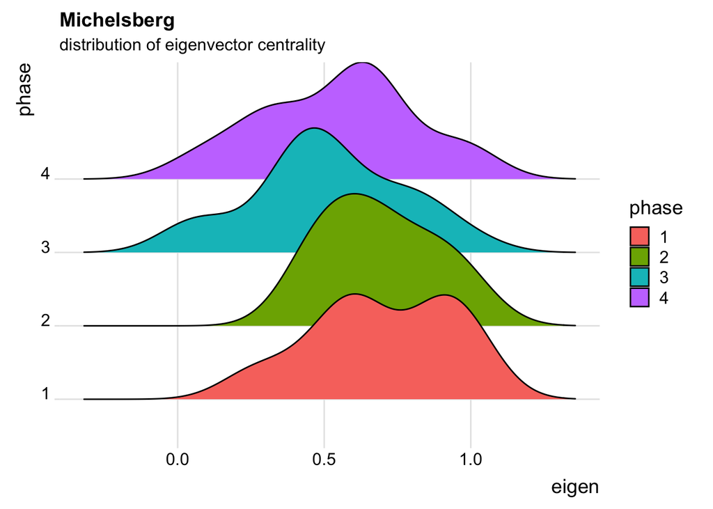

```r
centrality %>%
  select(phase, eigen) %>%   #select phase and eigenvector
  mutate(phase = as.factor(phase)) %>% #make sure data type is correct
  ggplot(                    #plot command
    aes(x = eigen,           #eigenvalue on the x axis
        y = phase,           #phase on the y axis
        fill = phase)        #phase for the series
  )+
  geom_density_ridges()+  #show density of the distribution on the ridge plot
  labs(title = "Michelsberg",
       subtitle = "distribution of eigenvector centrality" )+ #add some titles
  theme_ridges()  #select a graph visual theme
```

# Animation

Finally, just to whet your appetites, here is some code with which we can animate the networks to see the change over time.

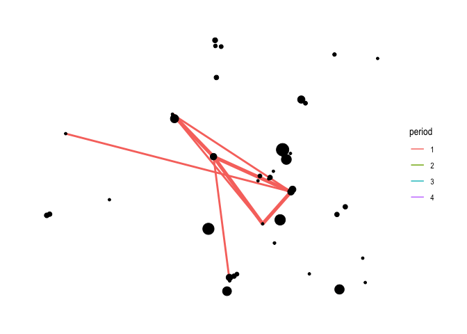

```r
#For this, we will join the networks together, with a note on the edges to say what period they are from. You could also do this straight from the beginning.

#Add phase column to edgelists
mbk1edges <- mbk1edges %>% mutate(period = 1) %>% mutate(period = as.factor(period))
mbk2edges <- mbk2edges %>% mutate(period = 2) %>% mutate(period = as.factor(period))
mbk3edges <- mbk3edges %>% mutate(period = 3) %>% mutate(period = as.factor(period))
mbk4edges <- mbk4edges %>% mutate(period = 4) %>% mutate(period = as.factor(period))

#join all edgelists into one
mbkedges <- bind_rows(mbk1edges, mbk2edges, mbk3edges, mbk4edges)

#make the overall network
mbknet <- tbl_graph(nodes = mbknodes, edges = mbkedges, directed = FALSE) %>%
  thresh.graph(4) # in this case, we will put a threshold in straight away

#Now for the animation:
p <- ggraph(mbknet, x = lon, y = lat)+  # we will choose a geographic layout
  geom_edge_link(aes(color = period, width = weight))+ #make the edges larger if they are strong, and color by period
  geom_node_point(aes(size = centrality_betweenness(weights = weight)))+ # size the nodes according to betweenness
  theme_graph()+                 # layout the background
  guides(size = FALSE, edge_width = FALSE)+  # keep only period in the legend
    transition_states(period,          # variable for animation
                    transition_length = 2, #length of transition
                    state_length = 1) #length of each state
anim <- animate(p)
anim_save("michelsber.gif", anim)
anim
```

Enjoy creating and evaluating your own networks using R!